# Stock Market Data Column Descriptions

### 1. **Open**

- **Definition**: The opening price of the stock on a given trading day. This is the first price at which the stock was traded after the market opened.
- **Usage**: Investors use the opening price to assess the initial market sentiment and compare it with other prices like the closing price.

### 2. **High**

- **Definition**: The highest price that the stock reached during the trading day.
- **Usage**: It shows the maximum value the stock traded at during the day and can be useful for understanding intraday volatility.

### 3. **Low**

- **Definition**: The lowest price that the stock traded at during the trading day.
- **Usage**: It reflects the minimum price of the stock, providing insight into the trading range for the day.

### 4. **Close**

- **Definition**: The final price at which the stock traded at the end of the trading day.
- **Usage**: The closing price is one of the most commonly referenced data points for evaluating a stock's daily performance.

### 5. **Adj Close (Adjusted Close)**

- **Definition**: The closing price of the stock adjusted for dividends, stock splits, or new stock issuance. This represents the stock’s true historical performance.
- **Usage**: Analysts and investors use the adjusted close to more accurately reflect the stock's historical price changes, particularly when analyzing long-term performance.

### 6. **Volume**

- **Definition**: The total number of shares that were traded during the trading day.
- **Usage**: Volume reflects the level of interest in the stock. Higher volume can indicate strong interest or major events affecting the stock, while lower volume may indicate less interest or fewer events influencing the stock's price.

```python
data.head(5)
```

| Date | Open | High | Low | Close | Adj Close | Volume |
| --- | --- | --- | --- | --- | --- | --- |
| 2011-01-03 | 11.630000 | 11.795000 | 11.601429 | 11.770357 | 9.939775 | 445138400 |
| 2011-01-04 | 11.872857 | 11.875000 | 11.719643 | 11.831786 | 9.991648 | 309080800 |
| 2011-01-05 | 11.769643 | 11.940714 | 11.767857 | 11.928571 | 10.073383 | 255519600 |
| 2011-01-06 | 11.954286 | 11.973214 | 11.889286 | 11.918929 | 10.065243 | 300428800 |
| 2011-01-07 | 11.928214 | 12.012500 | 11.853571 | 12.004286 | 10.137324 | 311931200 |

```python
data.tail()
```

| Date | Open | High | Low | Close | Adj Close | Volume |
| --- | --- | --- | --- | --- | --- | --- |
| 2024-08-26 | 226.759995 | 227.279999 | 223.889999 | 227.179993 | 227.179993 | 30602200 |
| 2024-08-27 | 226.000000 | 228.850006 | 224.889999 | 228.029999 | 228.029999 | 35934600 |
| 2024-08-28 | 227.919998 | 229.860001 | 225.679993 | 226.490005 | 226.490005 | 38052200 |
| 2024-08-29 | 230.100006 | 232.919998 | 228.880005 | 229.789993 | 229.789993 | 51906300 |
| 2024-08-30 | 230.190002 | 230.399994 | 227.479996 | 229.000000 | 229.000000 | 52990800 |

```python
data.info()
```

```
<class 'pandas.core.frame.DataFrame'>
DatetimeIndex: 3438 entries, 2011-01-03 to 2024-08-30
Data columns (total 6 columns):
 #   Column     Non-Null Count  Dtype
---  ------     --------------  -----
 0   Open       3438 non-null   float64
 1   High       3438 non-null   float64
 2   Low        3438 non-null   float64
 3   Close      3438 non-null   float64
 4   Adj Close  3438 non-null   float64
 5   Volume     3438 non-null   int64
dtypes: float64(5), int64(1)
memory usage: 188.0 KB
```

```python
data.describe()
```

|  | Open | High | Low | Close | Adj Close | Volume |
| --- | --- | --- | --- | --- | --- | --- |
| count | 3438.000000 | 3438.000000 | 3438.000000 | 3438.000000 | 3438.000000 | 3.438000e+03 |
| mean | 70.158573 | 70.906880 | 69.450675 | 70.209144 | 68.017699 | 2.072894e+08 |
| std | 61.256417 | 61.928287 | 60.642627 | 61.315789 | 61.741761 | 1.894870e+08 |
| min | 11.310000 | 11.346429 | 11.089286 | 11.261429 | 9.509997 | 2.404830e+07 |
| 25% | 23.452500 | 23.661250 | 23.180179 | 23.426428 | 20.429685 | 8.487580e+07 |
| 50% | 39.757502 | 40.026251 | 39.394999 | 39.662500 | 37.475798 | 1.339832e+08 |
| 75% | 128.957504 | 130.682507 | 127.425001 | 129.617496 | 127.188917 | 2.667854e+08 |
| max | 236.479996 | 237.229996 | 233.089996 | 234.820007 | 234.548523 | 1.880998e+09 |

```python
data.loc["2011-02-01"]
```

```
Open         1.218929e+01
High         1.234464e+01
Low          1.217786e+01
Close        1.232250e+01
Adj Close    1.040605e+01
Volume       4.266332e+08
Name: 2011-02-01 00:00:00, dtype: float64
```

```python
data.dtypes
```

```
Open         float64
High         float64
Low          float64
Close        float64
Adj Close    float64
Volume         int64
dtype: object
```

```python
data.duplicated().sum()
```

```
0
```

```python
data.isna().sum()
```

```
Open         0
High         0
Low          0
Close        0
Adj Close    0
Volume       0
dtype: int64
```

```python
data.count()
```

```
Open         3438
High         3438
Low          3438
Close        3438
Adj Close    3438
Volume       3438
dtype: int64
```

```python
data.size
```

```
20628
```

```python
data.shape
```

```
(3438, 6)
```

```python
data.columns
```

```
Index(['Open', 'High', 'Low', 'Close', 'Adj Close', 'Volume'], dtype='object')
```

```python
data.index
```

```
DatetimeIndex(['2011-01-03', '2011-01-04', '2011-01-05', '2011-01-06',
               '2011-01-07', '2011-01-10', '2011-01-11', '2011-01-12',
               '2011-01-13', '2011-01-14',
               ...
               '2024-08-19', '2024-08-20', '2024-08-21', '2024-08-22',
               '2024-08-23', '2024-08-26', '2024-08-27', '2024-08-28',
               '2024-08-29', '2024-08-30'],
              dtype='datetime64[ns]', name='Date', length=3438, freq=None)
```

```python
data.groupby("Month",observed=True).mean().round(2)
```

| Month | Open | High | Low | Close | Adj Close | Volume |
| --- | --- | --- | --- | --- | --- | --- |
| January | 66.46 | 67.21 | 65.72 | 66.50 | 64.32 | 2.394955e+08 |
| February | 68.13 | 68.85 | 67.43 | 68.22 | 66.07 | 2.250171e+08 |
| March | 66.84 | 67.67 | 66.11 | 66.91 | 64.76 | 2.299929e+08 |
| April | 68.04 | 68.72 | 67.40 | 68.05 | 65.86 | 2.247963e+08 |
| May | 69.28 | 69.98 | 68.62 | 69.31 | 67.22 | 1.953328e+08 |
| June | 70.74 | 71.51 | 70.12 | 70.83 | 68.73 | 1.761034e+08 |
| July | 76.34 | 77.11 | 75.69 | 76.49 | 74.31 | 1.725835e+08 |
| August | 79.45 | 80.29 | 78.74 | 79.55 | 77.38 | 2.013784e+08 |
| September | 68.22 | 68.90 | 67.24 | 68.00 | 65.68 | 2.314127e+08 |
| October | 66.52 | 67.31 | 65.87 | 66.67 | 64.34 | 2.135817e+08 |
| November | 69.42 | 70.13 | 68.74 | 69.50 | 67.28 | 1.908949e+08 |
| December | 71.42 | 72.13 | 70.65 | 71.39 | 69.16 | 1.894430e+08 |

- **the European debt crisis and its potential effect on global markets lead to drop in Apple's stock**
- **Apple's stock experienced a sharp decline in early 2013, largely due to concerns over slowing growth in iPhone sales and increased competition in the smartphone market. Additionally, Apple's earnings report for the fourth quarter of 2012 showed lower profit margins, raising fears about the company's ability to maintain its profitability. Investor sentiment also worsened as the stock had risen dramatically in previous years, leading to profit-taking and a broader market correction**
- **Apple's stock experienced a significant decline in December 2015, largely due to concerns about slowing iPhone sales. Analysts began questioning whether Apple had reached "peak iPhone," as the company relied heavily on iPhone sales for its revenue. There were also concerns about economic conditions in China, one of Apple's key markets. This led to investor uncertainty, causing the stock price to drop**
- **COVID-19 Pandemic & Supply Chain Disruptions caused the drop of 2020: The outbreak led to widespread economic uncertainty and a decline in consumer spending, significantly impacting Apple's sales and supply chains. Lockdowns and factory closures in China disrupted Apple's production and product availability, raising concerns among investors**.

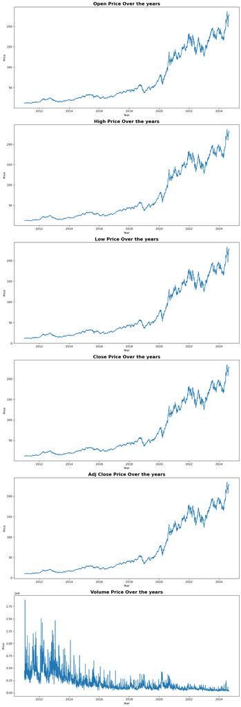

```python
f,ax = plt.subplots(data.shape[1]-2,1,figsize=(12,35))
for i,c in enumerate(data.columns[:-2]):
    ax[i].plot(data.index, data[c])
    ax[i].set_title(f"{c} Price Over the years",weight='bold',fontsize=16)
    ax[i].set_xlabel("Year")
    ax[i].set_ylabel("Price")
plt.tight_layout()
plt.show()
```

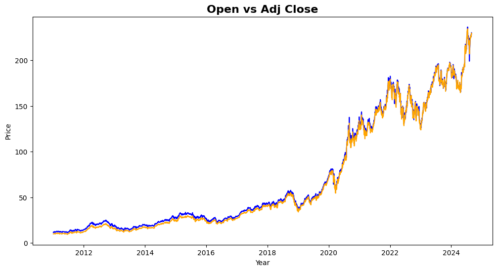

```python
plt.figure(figsize=(12,6))
plt.title("Open vs Adj Close",weight='bold',fontsize=16)
plt.plot(data.index,data.Open,color='blue')
plt.plot(data.index,data["Adj Close"],color='orange')
plt.xlabel("Year")
plt.ylabel("Price")
plt.show()
```

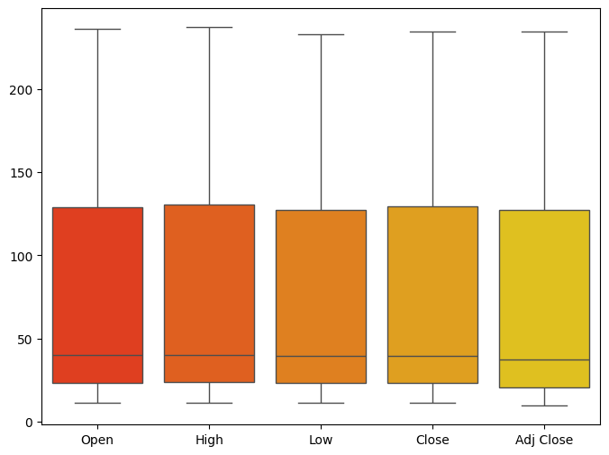

```python
f,ax = plt.subplots(figsize=(8,6))
sns.boxplot(data=data[["Open","High","Low","Close","Adj Close"]],palette='autumn',ax=ax)
```

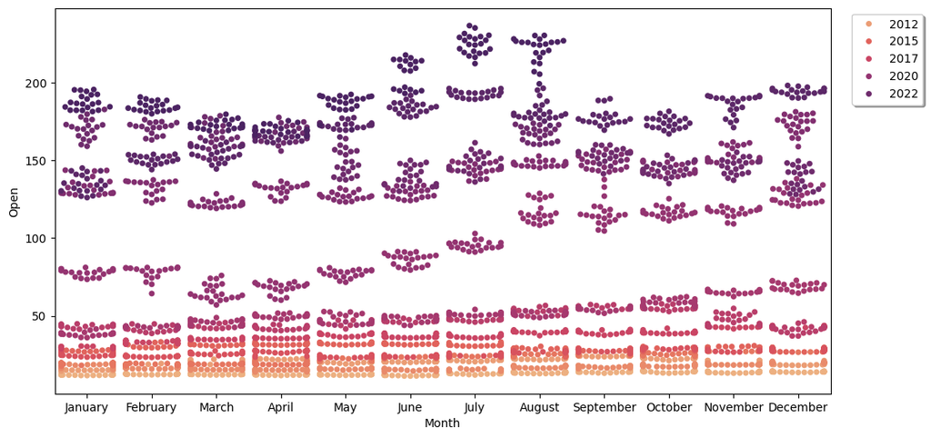

```python
ax = plt.subplots(figsize=(12,6))
sns.swarmplot(data=data,x='Month',y='Open',hue='year',palette='flare',ax=ax[1])
ax[1].legend(shadow=True,bbox_to_anchor=(1.02,1))
```

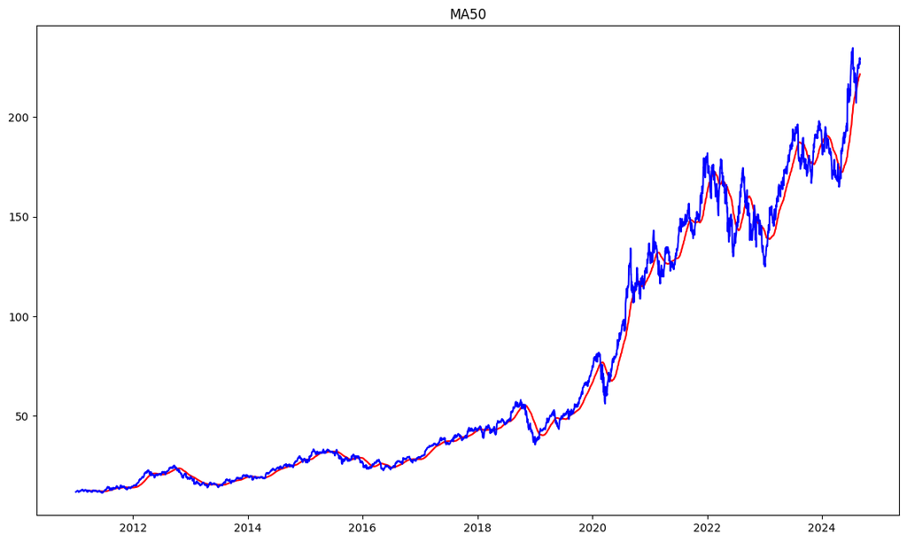

```python
ma_50 = data.Close.rolling(50).mean()
plt.figure(figsize=(14,8))
plt.title("MA50")
plt.plot(ma_50,color='r')
plt.plot(data.Close,color='b')
plt.show()
```

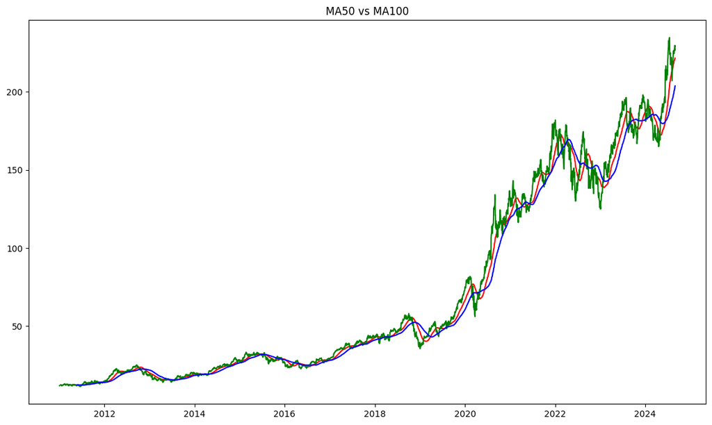

```python
ma_100 = data.Close.rolling(100).mean()
plt.figure(figsize=(14,8))
plt.title("MA50 vs MA100")
plt.plot(ma_50,color='r')
plt.plot(data.Close,color='g')
plt.plot(ma_100,color='b')
plt.show()
```

```
(-1.0, 1.1)
```

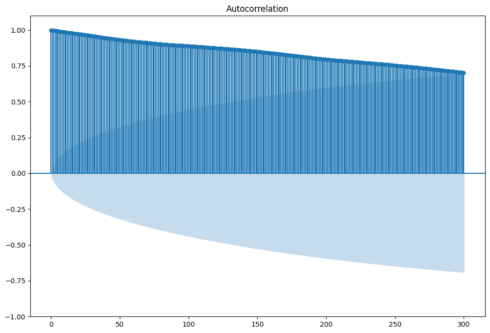

```python
f,ax = plt.subplots(figsize=(12,8))
plot_acf(df,lags=300,ax=ax)
plt.ylim(-1,1.1)
```

```
(-1.0, 1.1)
```

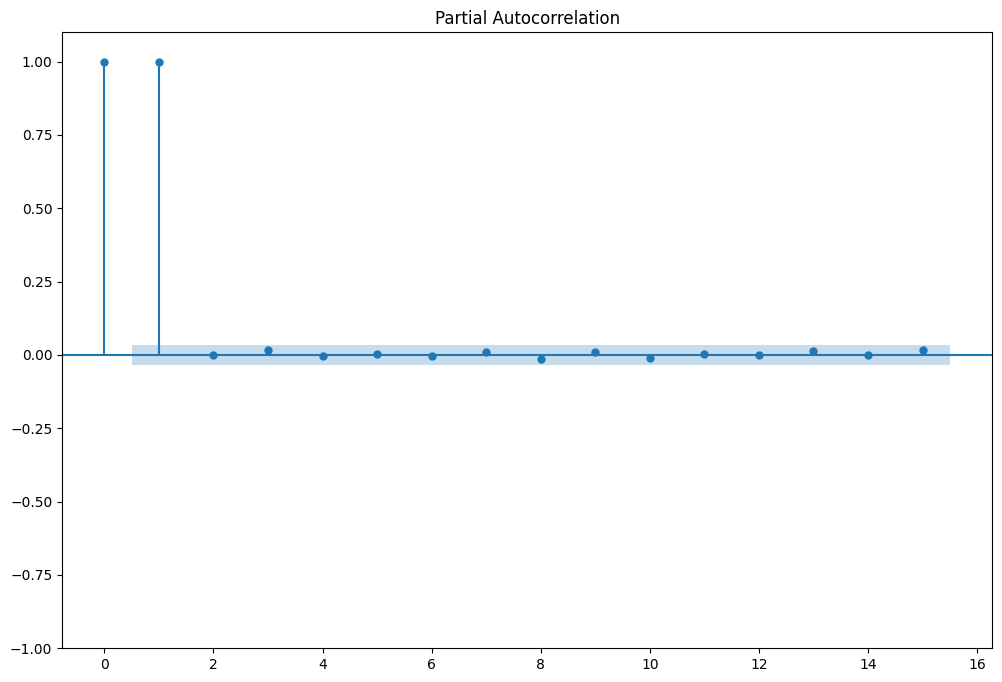

```python
f,ax = plt.subplots(figsize=(12,8))
plot_pacf(df,lags=15,ax=ax)
plt.ylim(-1,1.1)
```

- **ACF Indicates Number of lags in MA Model**
- **PACF Indicates Number of Lags in AR Model**

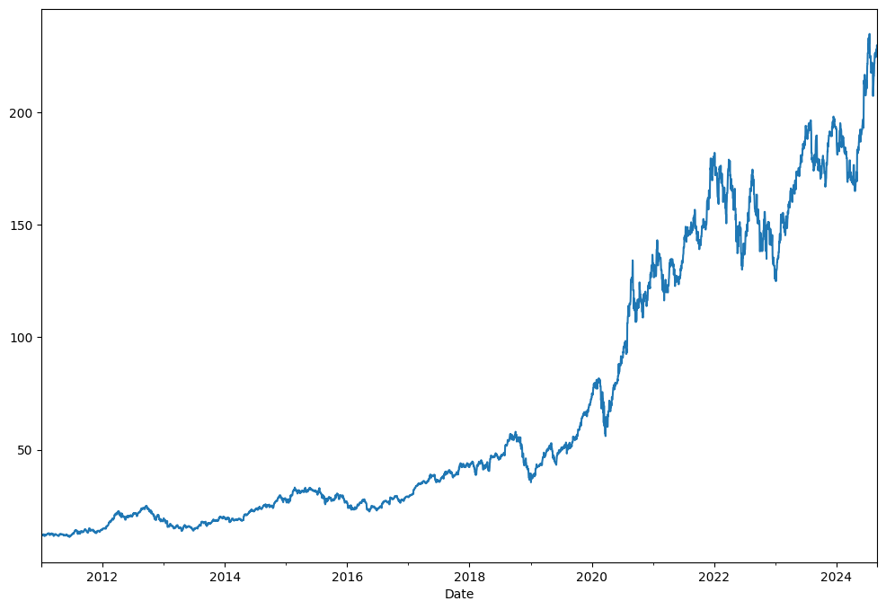

```python
plt.figure(figsize=(12,8))
df2.plot()
```

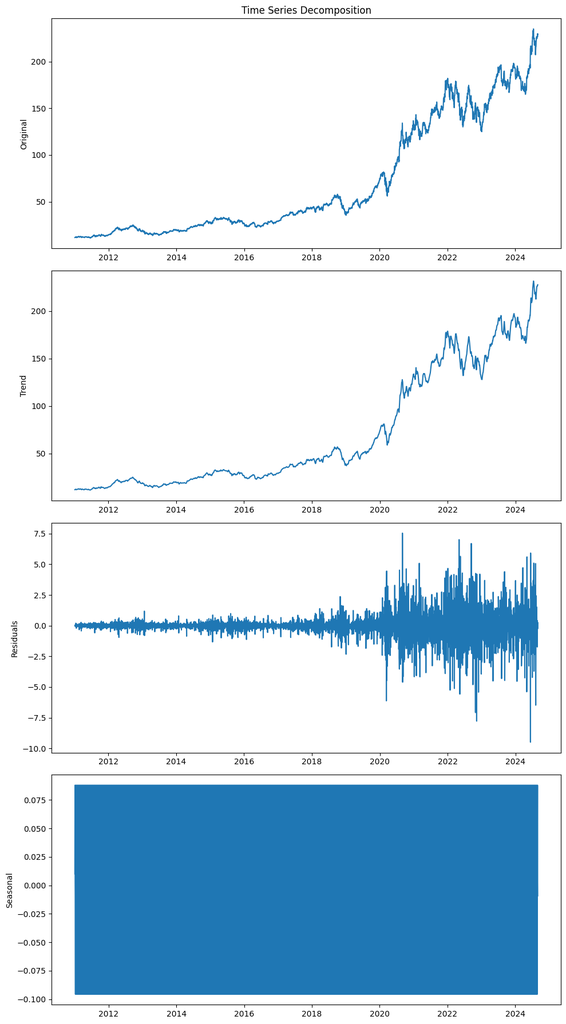

```python
f,ax = plt.subplots(4,1,figsize=(10,18))
ax[0].plot(df2)
ax[0].set_title("Time Series Decomposition")
ax[0].set_ylabel("Original")
ax[1].plot(trend)
ax[1].set_ylabel("Trend")
ax[2].plot(residuals)
ax[2].set_ylabel("Residuals")
ax[3].plot(seasonal)
ax[3].set_ylabel("Seasonal")
plt.tight_layout()
```

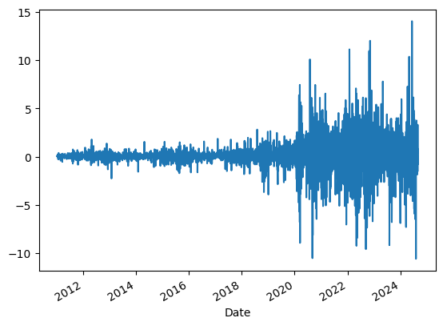

```python
df.diff().dropna().plot()
```

```
(-1.0, 1.05)
```

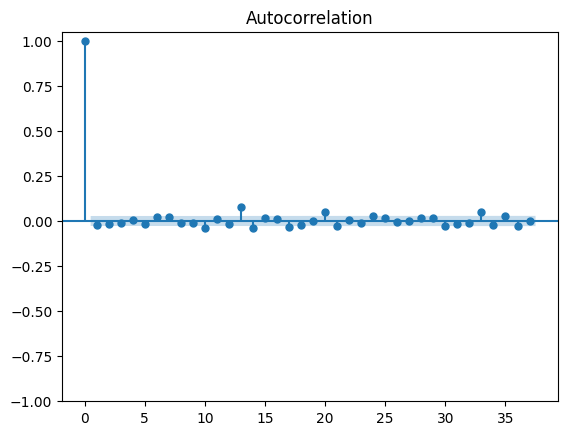

```python
plot_acf(df_diff)
plt.ylim(-1,1.05)
```

```
(-1.0, 1.05)
```

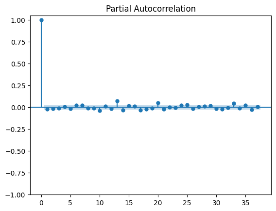

```python
plot_pacf(df_diff)
plt.ylim(-1,1.05)
```

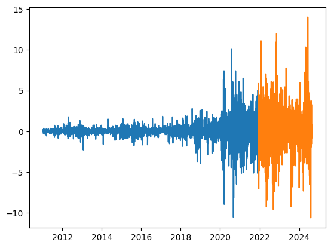

```python
plt.plot(train)
plt.plot(test)
```

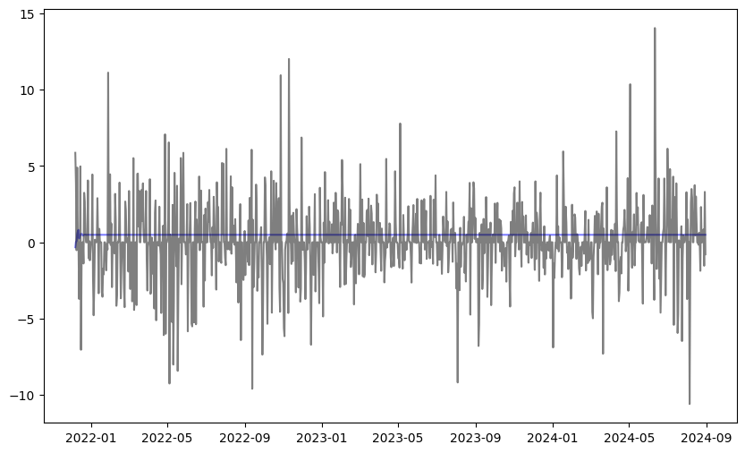

```python
plt.figure(figsize=(10,6))
plt.plot(preds,color='b',alpha=0.5)
plt.plot(test,color='k',alpha=0.5)
```

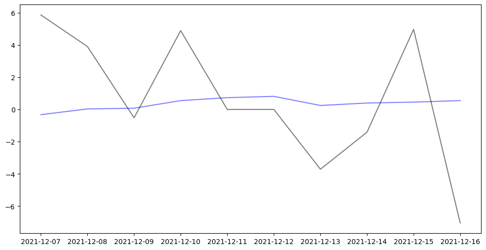

```python
plt.figure(figsize=(12,6))
plt.plot(preds,color='b',alpha=0.5)
plt.plot(test.iloc[:10],color='k',alpha=0.5)
```

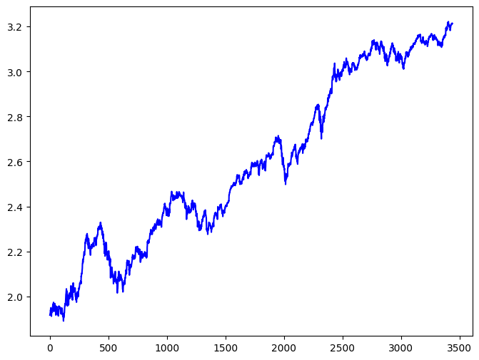

```python
plt.figure(figsize=(8,6))
plt.plot(log_data2,color='blue')
```

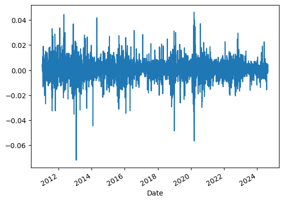

```python
df4.plot()
```

```
(-1.0, 1.1)
```

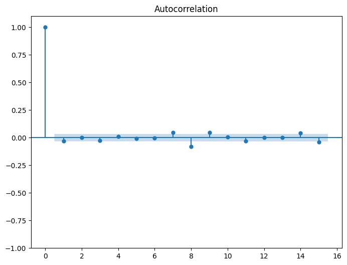

```python
f,ax = plt.subplots(figsize=(8,6))
plot_acf(df4,lags=15,ax=ax)
plt.ylim(-1,1.1)
```

```
(-1.0, 1.1)
```

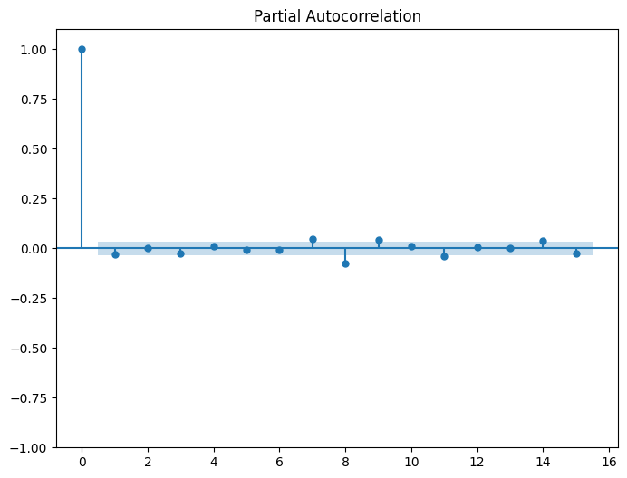

```python
f,ax = plt.subplots(figsize=(8,6))
plot_pacf(df4,lags=15,ax=ax)
plt.ylim(-1,1.1)
```

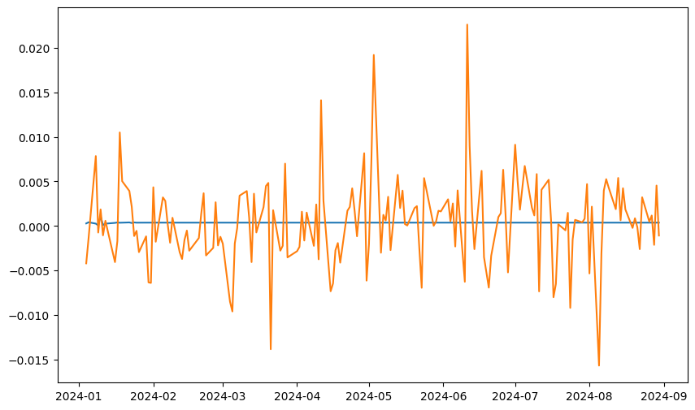

```python
plt.figure(figsize=(10,6))
plt.plot(s_pred)
plt.plot(test_data)
```

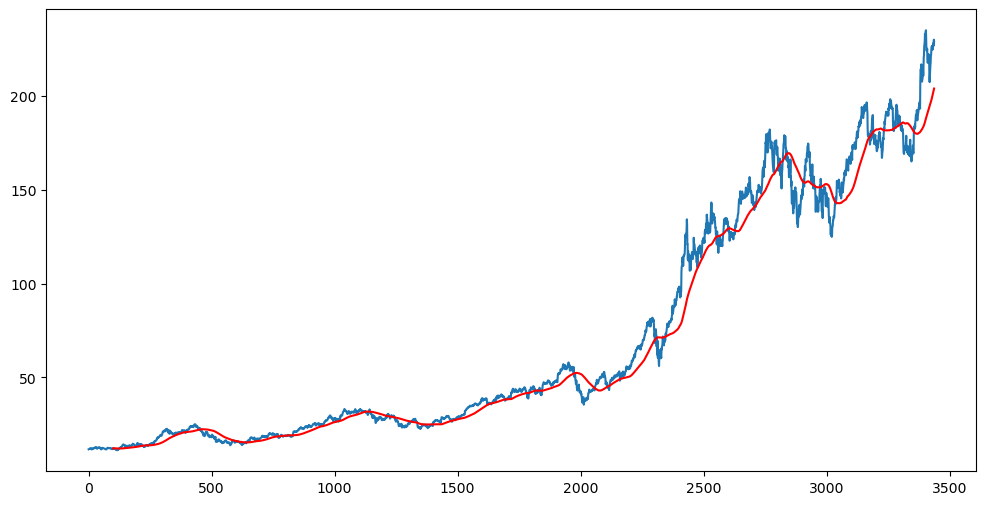

```python
ma_100 = data.Close.rolling(100).mean()
plt.figure(figsize=(12,6))
plt.plot(data.Close)
plt.plot(ma_100,color='r')
plt.show()
```

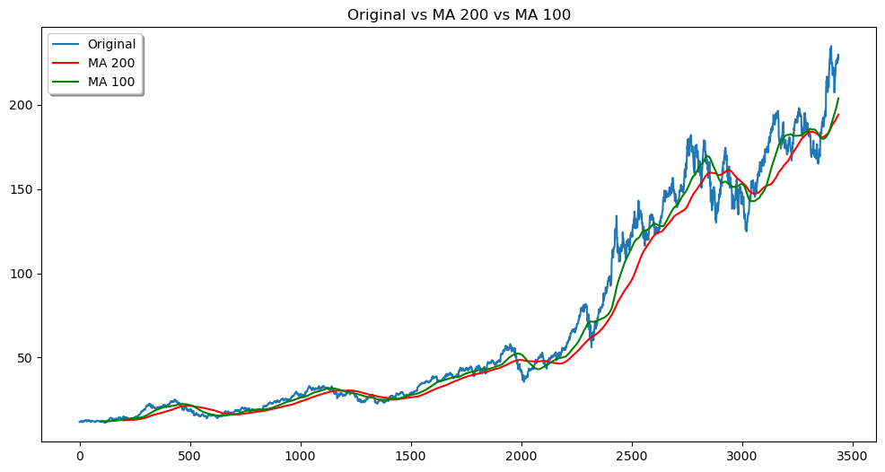

```python
ma_200 = data.Close.rolling(200).mean()
plt.figure(figsize=(12,6))
plt.title("Original vs MA 200 vs MA 100")
plt.plot(data.Close,label='Original')
plt.plot(ma_200,color='r',label='MA 200')
plt.plot(ma_100,color='g',label="MA 100")
plt.legend(shadow=True)
plt.savefig('Rolling_windows.png',dpi=300)
plt.show()
```

```python
print(model.summary())
```

```
Model: "sequential"
```

```
┏━━━━━━━━━━━━━━━━━━━━━━━━━━━━━━━━━━━━━━┳━━━━━━━━━━━━━━━━━━━━━━━━━━━━━┳━━━━━━━━━━━━━━━━━┓
┃ Layer (type)                         ┃ Output Shape                ┃         Param # ┃
┡━━━━━━━━━━━━━━━━━━━━━━━━━━━━━━━━━━━━━━╇━━━━━━━━━━━━━━━━━━━━━━━━━━━━━╇━━━━━━━━━━━━━━━━━┩
│ lstm (LSTM)                          │ (None, 100, 50)             │          10,400 │
├──────────────────────────────────────┼─────────────────────────────┼─────────────────┤
│ dropout (Dropout)                    │ (None, 100, 50)             │               0 │
├──────────────────────────────────────┼─────────────────────────────┼─────────────────┤
│ lstm_1 (LSTM)                        │ (None, 100, 60)             │          26,640 │
├──────────────────────────────────────┼─────────────────────────────┼─────────────────┤
│ dropout_1 (Dropout)                  │ (None, 100, 60)             │               0 │
├──────────────────────────────────────┼─────────────────────────────┼─────────────────┤
│ lstm_2 (LSTM)                        │ (None, 100, 80)             │          45,120 │
├──────────────────────────────────────┼─────────────────────────────┼─────────────────┤
│ dropout_2 (Dropout)                  │ (None, 100, 80)             │               0 │
├──────────────────────────────────────┼─────────────────────────────┼─────────────────┤
│ lstm_3 (LSTM)                        │ (None, 120)                 │          96,480 │
├──────────────────────────────────────┼─────────────────────────────┼─────────────────┤
│ dropout_3 (Dropout)                  │ (None, 120)                 │               0 │
├──────────────────────────────────────┼─────────────────────────────┼─────────────────┤
│ dense (Dense)                        │ (None, 1)                   │             121 │
└──────────────────────────────────────┴─────────────────────────────┴─────────────────┘
```

```
 Total params: 536,285 (2.05 MB)
```

```
 Trainable params: 178,761 (698.29 KB)
```

```
 Non-trainable params: 0 (0.00 B)
```

```
 Optimizer params: 357,524 (1.36 MB)
```

```
None
```

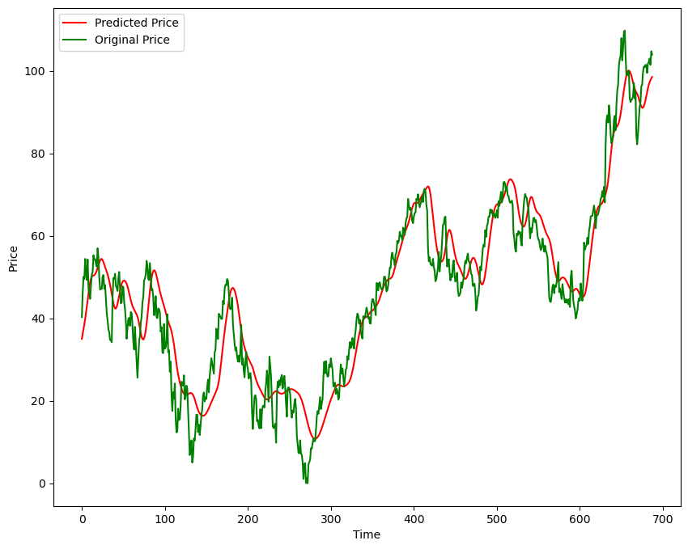

```python
plt.figure(figsize=(10,8))
plt.plot(y_pred,color='r',label="Predicted Price")
plt.plot(y,color='g',label="Original Price")
plt.xlabel("Time")
plt.ylabel("Price")
plt.legend()
plt.savefig('model_prediction.png',dpi=300)
plt.show()
```